# What a Clusterf*ck! Making Sense of State-Level Immigration Policy

Author

Nathaniel Cross

University

The University of Arizona

Advisor

Adam Douglas Henry

School

School of Government and Public Policy

Published

May 12, 2026

## Introduction

In 2010, Arizona Governor Jan Brewer signed Senate Bill 1070 into law, the first of many state-level omnibus immigration bills implementing strict immigration enforcement measures across states. Soon after, a wave of copycat bills were proposed across the country, with laws enacted in Alabama, Georgia, Indiana, South Carolina, and Utah (“SB 1070 at the Supreme Court,” n.d.). After an onslaught of legal battles, the Supreme Court eventually struck down three of four provisions of SB 1070, leaving the controversial “show me your papers” provision standing. Arizona SB 1070 marked a major divergence of state policy from federal standards and further incited increasingly diverse state-level immigration policies across the nation.

Immigration policy has been a longstanding federal policy arena—not a state one. However since the 9/11 terror attacks in 2001, immigration policy has become much more salient in the eyes of the American public. Indeed, in pre-election polling in 2024, immigration consistently ranked as one of the top issues informing electoral decisions among U.S. voters. According to a late August 2024 survey conducted by Pew Research, 61% of all voters found immigration as very important to their vote in the presidential election (“In Tied Presidential Race, Harris and Trump Have Contrasting Strengths, Weaknesses,” 2024). Immigration was also one of the issues facing the greatest partisan split, suggestive of its highly polarized nature. Eighty-two percent of Trump supporters found immigration very important to their vote, whereas only 39% of Harris supporters said the same. The increasing salience and polarization of immigration policy may serve as one reason why states have chosen to adopt increasingly frequent and diverse immigration policies, introducing questions of the balance in policymaking between the federal and state arenas.

The U.S. governmental structure—a federalist one—was created to enable heterogeneity in certain policy areas across states, with the canonical intent to allow state policymakers to enact laws that most closely mirrored the needs and desires of their direct constituents and local contexts. Throughout this county’s history, pendulum swings have tilted the balance of federal to state policymaking primacy and back again. Recent efforts to shrink the federal government and rely predominantly on state policymaking by the first and second Trump Administrations have incited debates over the role of states in policy areas that have traditionally been the arena of the federal government, like immigration policy. However, increasing state policies and policy diversity means the nationwide immigration policy profile has become highly individualized and fragmented, with vastly different expectations of and treatment towards immigrants based on geography. In response, the literature on immigration policy has adjusted to better analyze the role of state-level jurisdictions in policymaking, as well as heterogeneity across this policy type.

## Literature Review

### Immigration policy through the lens of federalism

Although Arizona SB 1070 marked a contemporary and drastic furtherance of immigration policy into the state domain, policy literature has analyzed the role of federalism and diverging state and federal roles in immigration policymaking in the United States since the 1990s. Immigration law experts of the era consider Clinton’s Personal Responsibility and Work Opportunity Reconciliation Act (PRWORA) (1996) to mark the first policy devolution from the federal to the state level (Spiro, 1997). Initially, increasing state primacy in immigration policy was rooted in the changes made to public welfare programs, such as the replacement of Aid to Families with Dependent Children (AFDC) with the Temporary Assistance for Needy Families (TANF) program (“The Personal Responsibility and Work Opportunity Reconciliation Act of 1996,” 1996). Overall, PRWORA established much stricter conditions for receipt of public assistance, such as work requirements and five-year lifetime limit. Most importantly, it awarded state governments much greater control over public welfare policy, enabling vast heterogeneity in welfare distribution between states. This state-level control was the first (since the 1800s) shift towards state primacy in immigration policymaking, and states soon began implementing more and more diverse immigrant public benefits policies, including subversions of public welfare provisions established at the federal level in PRWORA. This late-1990s policy divergence as well as attention in policymaking literature marked the very beginning of increasing state primacy: in the 2000s, following the 9/11 terror attacks in 2001, state-level immigration legislation exploded, this time with waves of increasing anti-immigrant enforcement policies.

This stark shift in responsibility of public welfare program policymaking and administration is critical due to the legal and constitutional foundations of federal immigration primacy. Since the Civil War, the federal government has retained primacy in matters of immigration policy, predominantly affirmed by Supreme Court rulings in the late 1800s and into the 1900s. Henderson v. Mayor of New York (1875) found New York and Louisiana statutes that regulated the admission of immigrants through the port of New York unconstitutional, on the ground that they infringed upon federal power to regular commerce with foreign nations. Similarly, Chy Lung v. Freeman (1875) affirmed the primacy of Congress in passing laws that “concern the admission of citizens and subjects of foreign nations to our shore.” Federal primacy continued to hold strong—backed by judicial rulings—through the mid-to-late 1900s. Graham v. Richardson (1971), Mathews v. Diaz (1976), and Plyler v. Doe (1982)—all cases where the federal judiciary is ruling on state laws—all sided with federal preemption, the legal concept that laws of a higher authority will supersede laws of a lower authority when the two come into conflict (Motomura, 2010). Such legally-rooted federal primacy means that deviations in such tradition—as explored by Spiro regarding state-level administration of public welfare programs, as well as enforcement measure expansion at the state level throughout the 2000s—represent a meaningful and legally-contested departure from the established order. Widespread adoption of 287(g) programs and omnibus immigration bills are not merely a natural extension of states’ traditional policing powers, but rather a schism in immigration policymaking.

Other immigration law scholars point to the longstanding informal role of states in immigration due to the inherent federalist structure of government and division of governance responsibilities between the federal and state governments. Indeed, states have exercised informal roles in labor markets, education, social services, and law enforcement—all of which interact, directly or indirectly, with immigration, thereby implicating states—to some degree, however minor—in immigration policymaking (Schuck, 2009). Schuck argues that these once-sidelined roles began to become formalized through legislative action around the turn of the century, helping explain how the heterogeneity in state is not anomalous, but rather immigration policy is a structural legal and legislative feature of American governance.

### Roots of contemporary immigration policy salience

The years surrounding 2000 mark the beginning of increased state roles in immigration policymaking, as established. This followed a decade of stark anti-immigrant sentiment that defined the 1990s. For example, California—now considered a hallmark of pro-immigrant progressive legislation—pioneered anti-Asian immigrant policies such as their 1994 Proposition 187, which denied unauthorized immigrants a range of public services (Capps, 2009). Additionally, immigration enforcement was growing, with regular increases in Customs and Border Patrol budget awarded annually (“The Cost of Immigration Enforcement and Border Security,” 2024). The 1993 Operation Hold the Line, established in El Paso, concentrated resources—both personnel and capital—in specific areas to provide a “show of force” to potential unauthorized border crossers. Similarly, Operation Gatekeeper in 1994 served as a San Diego expansion of Hold the Line and drastically increased border enforcement measures across the Southern border (“Border Patrol History,” 2026).

Then in 1996, two federal policies—PRWORA and the Illegal Immigration Reform and Immigrant Responsibility Act (IIRIRA)—set the tone for structural changes to immigration policy in the 2000s as both were passed by the same Clinton-Gingrich Congress as part of massive overhauls to the national welfare and immigration systems, prioritizing greater “personal responsibility.” Both of these acts, representing devolution of immigration policy, restructured the relationship between states and immigrant populations by permitting, and in certain cases encouraging, states to restrict access to means-tested public welfare benefits (Wishnie, 2001). This was primarily accomplished through the introduction of the “five-year bar,” a public benefits eligibility requirement set by PRWORA that prevented Legal Permanent Residents (LRPs) from accessing public welfare programs like TANF during the first five years of their residency in the United States. Because the five-year bar created a federal floor of exclusion rather than a national standard, states were left to individually decide whether to extend coverage to LPRs during the five-year bar, which produced high heterogeneity among states (Borjas, 2003).

The 9/11 terror attacks also marked an important substantive shift in how immigration policy was viewed in the United States. Following 9/11, the Immigration and Naturalization Service (INS) (once a federal agency responsible for overseeing immigration, naturalization, border patrol, and immigration enforcement from 1933 to 2003) was replaced by the Department of Homeland Security, through the three major arms of contemporary immigration bureaucracy: U.S. Citizenship and Immigration Services (USCIS), Immigration and Customs Enforcement (ICE), and Customs and Border Patrol (CBP). This shift in bureaucratic objectives marked the subordination of immigration policy to terrorism policy, losing its independent agenda (Tumlin, 2004). This shift changed the structural considerations of immigration policy: now housed within a security apparatus, immigrants, including refugees and asylees, were now processed through an organization whose first instinct was suspicion rather than acceptance. These changes wreaked massive impacts on immigration policy nationwide. At the federal level, existing negotiations for a legalization program for long-term Mexican immigrants was immediately abandoned, refugee admissions were frozen, and immigration courts were closed to the public in “special interest” cases, thereby insulating the racial-, or immigrant-profiling regime from public scrutiny. At the state level, 287(g) programs were rapidly adopted. Initially established in the Illegal Immigration Reform and Immigrant Responsibility Act, 287(g) programs allow U.S. Immigration and Customs Enforcement to deputize local law enforcement officers to carry out duties of federal immigration officers. After the first agreement between the federal government and a law enforcement agency in Florida in 2002, adoption of 287(g) agreements surged across the country, with early adopters like Alabama, Arizona, and California in the 2003-2006 range before 26 total law enforcement agencies signed on in 2007 (Capps, 2009). These programs extended state immigration authority through their existing policing responsibility, in alignment with the devolution mechanism proposed by Schuck.

### Describing a typology of state immigration policies

With the growing diversity of state-level immigration policies since the 1990s and 2000s, scholars have attempted to categorize or group policies into various typologies. Walker & Leitner offer a formal binary typology in evaluating types of immigration policies that is bifurcated by inclusionary and exclusionary policies (Walker & Leitner, 2011). Exclusionary policies include programs like 287(g) agreements, English-only ordinances, day-labor restrictions and housing/zoning restrictions. Inclusionary policies include sanctuary ordinances, extension and strengthening of immigrant suffrage enfranchisement, and acceptance of consular identification cards. These authors ultimately propose a “variegated landscape” of immigration policies.

Filindra & Kovacs continue to build on the binary typology utilized by Walker & Leitner by analyzing immigration-related legislative resolutions from Southern border states using a dual-axis typology (2012). The first describes the degree of federal responsibility states choose to engage with in their policymaking (i.e. degree of federalism), and the second describes the integrative versus exclusionary posture of the resolution. The authors also begin to explore other dimensions of policy types, such as enforcement- or integration-forward. Among border states analyzed, Filindra & Kovacs specifically highlight Arizona’s threat/catastrophe framing, heavy use of “illegal” terminology, and emphasis of border militarization and deportation as diametrically opposed to California and New Mexico, which use value-neutral and rights-protective language and focus policy content on cost of services, immigrant rights, and naturalization pathways.

Ultimately, while a binary typology provides a logical starting place to categorize immigration policies, dimensions of immigration policy are deeper than pro- and anti-immigrant sentiment or objective. Dividing policy types into dimensions that describe their content has been found to more meaningfully describe the policy space. Categories like enforcement, integration, and economic/labor force integration are commonly used throughout the literature.

### Single-metric studies and the need for multidimensional analysis

Often, the immigration policy literature will choose a specific dimension of immigration policy to investigate, commonly as an independent variable and examining effects on immigrant integration, health, or education as outcomes of interest. While organizing an investigation around a single policy type enables a deep analysis of specific mechanisms, it limits the generalizability of findings to broader state policy profiles. Examples of investigations like this include Kostandini et al. in an investigation of immigration enforcement on labor market consequences, specifically in the agricultural sector (2014). However, the article solely uses adoption of 287(g) programs as a proxy for immigration enforcement, ultimately demonstrating that county-level adoption reduced immigrant presence in adopting jurisdictions. Although this illustrates the depth of analysis achievable with a single-policy study, this study is also limited in its ability to speak to the entire diorama of enforcement policies, as whether 287(g) program adoption is part of a broader enforcement-oriented policy profile or an isolated policy choice is forgone in this investigation. But using specific policies—namely 287(g) agreements as a proxy for immigration enforcement or enforcement intensity—is not limited to Kostandini et al.: Capps et al. (2011), Wong (2012), and Nguyen & Hill (2016) all suffer the same construct validity issue as Kostandini et al. Because each of these—among others, overutilization of 287(g) programs as single-metric proxies are the example chosen for this review—isolates a single policy, they are lacking the ability to inform the literature of the holistic policy environment surrounding the 287(g) program, yielding questions related to the immigration enforcement environments in the jurisdictions of analysis, as well as potential overstating of treatment effects if specifications suffer from omitted variable bias due to the omission of other enforcement programs that make up a jurisdiction’s enforcement policy profile beyond 287(g) agreements.

Addressing this gap requires a more complete analytic approach which attempts to identify trends and roles of a wider, and more complete, range of immigration policies—not just limited to enforcement policies, but also expansive of other dimensions of policy, such as integration and public benefits. Wallace et al. provide such a framework, constructing an “inclusion score” that aggregates multiple policy types into a single metric of state-level inclusion towards immigrants (2019). Policy types included span five self-defined dimensions of immigration policy: public health and welfare benefits, higher education, labor and employment, drivers’ licenses, and immigration enforcement. Here, the indexing of this metric accounts for a much broader range of policy types than other studies that rely on limited policies as proxies for policy dimensions. Other descriptive techniques, like factor or cluster analysis could also serve to better represent the diversity of immigration policy types, in a manner similar to the indexing in Wallace et al.

Ultimately, historical policy implementations—beginning with Clinton-era “personal responsibility”-based reforms to the public welfare and immigration sectors and continuing into the 2000s—have caused devolution in immigration policy, limiting federal primacy for an increased role of state governments. Consequently, there has evolved vast fragmentation in the immigration policy space due to the aforementioned devolution, with competing frameworks, contexts, and goals in the state policymaking arena. Such fragmentation can hold immense equity consequences for immigrant populations across the nation, as state of residence can significantly impact quality of life for immigrants, including sense of belonging and personal health and wellbeing. Patchworked state immigration policies not only create administrative inefficiencies and challenges to federal enforcement, but also unequal treatment of similarly-situated immigrants across state lines. And while “voting with one’s feet” is often an argument in favor of distinctive state-level policy environments, immigrants often find themselves systemically underresourced, limiting their abilities to change the policy environment in which they reside. These equity concerns are furthered when potential impacts on immigrants’ economic mobility, health, and civic participation are also considered. State-level variation has real and consequential human impacts and warrants further investigation into characteristics and drivers of state-level heterogeneity.

### Research Questions

The dynamics of the literature surrounding state-level immigration policy motivated an exploratory investigation into the metrics, qualities, and implications of state policy profiles. The overarching goal was set to identify trends, groupings, and patterns in state policies, not only across units of analysis, states, but also across time. As evidenced by the immigration policy literature, this policy area has become increasingly salient, complex, and polarized over the past two decades. An analysis of this timeframe was designed to yield results that were both contemporarily relevant yet historically rooted, with enough temporal backing to ground results and contribute to internal validity. With these goals in mind, the following research questions were drafted:

1. How can state-level immigration policy be characterized? How can states be grouped together? What trends exist across geography and time?
2. What are determinants of state-level immigration policy? Is state government partisanship an important driver of a state’s policy profile?

These questions—exploratory in nature—were responded to through a dual-stage cluster analysis process. A secondary goal of the investigation revolved around visualizing multi-dimensional data to best identify clusters of states and communicate findings. Ultimately, this study aims to broaden our understanding of determinants and characterizations of state-level immigration policy profiles.

## Research Design

### Methodology

Quantitative methods frequently serve as the backbone of internally and externally valid investigations in the policy analysis literature. This study continues that trend by utilizing a rich panel dataset which is subjected to cluster and regression analyses. The quantitative approach enables a systematic identification of trends and patterns across the large, 51-state and 20-year dataset. It offers a rigorous descriptive and exploratory approach, yielding insights into state immigration policy profiles and their determinants. This study employs a two-stage quantitative design: an exploratory cluster analysis stage that characterizes and categorizes state policy profiles, followed by a confirmatory regression stage that identifies determinants of cluster membership.

The data analysis was conducted predominantly using cluster analysis, which served as a strong exploratory and descriptive analysis technique. Cluster analysis was best suited to the research questions of this study as it was most appropriate for the goals, namely in its interpretability, use of states (instead of policies) as units, and ease of harmonization across years. Other methods, like exploratory factor analysis and principal-component analysis, were rejected primarily for their inability to be harmonized, or aligned, across years due to their focus on policy groupings instead of state groupings.

Employment of brief case studies helps bring a more qualitative element to this analysis and contextualizes findings in more tangible geographic, temporal, and policy contexts.

### Data

The primary dataset was generated from the Urban Institute’s State Immigration Policy Resource (Hamutal Bernstein et al., 2022; Julia Gelatt et al., 2017). This dataset documents 25 immigration policies that (mostly) fall into the state policymaking arena. All fifty states and the District of Columbia are represented, as well as all years from 2000 to 2020. The initial dataset was created through 2017, with the final update added in 2022, yielding a final 21-year dataset. While a few missing values were present in the dataset from limitations during the coding process, ultimately many of these values were fixed during analysis through additional coding. However, due to excess missing and the irregularity of policy, government, and society that year, the final range of years only includes 2000 through 2019 (2020 was cut). The policies included in the dataset vary across a wide range of areas, however can be categorized into three main groups: enforcement policies, public benefits policies, and integration policies, following typologies established in the literature. Examples of enforcement policies include various types of 287(g) programs or E-Verify policies, which requires local employers to confirm the employment eligibility of workers. Public benefits policies mainly center around means-tested benefits which are mostly distributed at the state-level; many policies either uphold or workaround the five-year bar. Examples include Medicaid for pregnant LPRs during the five-year bar, or TANF (Temporary Assistance for Needy Families) after the five-year bar. Finally, integration policies include policies like in-state tuition or state financial aid regardless of immigration status, or a ban on university enrollment for unauthorized immigrants. More information on these policies can be found here. These policies served as the vector of values for each state-year that informed the k-means clustering process, and also enabled greater interpretability of cluster results by application to real-world policy contexts.

A variety of supplemental datasets were also used for further data cleaning or secondary analyses. The USPS State Abbreviations table was used to identify states by two-letter abbreviations in the Urban Institute data. For the determinants of cluster membership regression, a multitude of datasets were utilized. First, demographic variables were sourced from one-year estimates of the American Community Surveys from 2006 to 2019 as well as the 2000 U.S. Decennial Census (U.S. Census Bureau, n.d.-a, n.d.-b). These demographic variables included raw population as well as population proportions for the following groups: white, Latino, foreign-born, undocumented, old (aged 65+), unemployed, and living in poverty. Values for 2001 through 2005 (missing in the above data sources) were imputed with a linear prediction model using surrounding values from 2000 and 2006. Additionally, the proportion of undocumented immigrants in each state each year was included in this model, the data for which was garnered from the Pew Research Center for the years 2000-2009 and from the Center for Migration Studies, for 2010-2019 (2022; 2019). Raw estimates of undocumented immigrants were divided by state-year populations from the ACS/Census data to yield proportions. Finally, state government partisanship was derived from Klarner’s State Partisan Balance Data for years 2000 to 2011, and supplemented with National Conference of State Legislatures data up to 2019 (2013; 2026). These data sources were selected given their academic rigor, historical use in similar investigations of state-level policy determinants, and timeframes available.

### Methods

Two forms of cluster analysis drove the analysis and results presented below. First, hierarchical clustering was used to gain a more comprehensive understanding of the structure of the data, including an empirically-informed ideal k number of groups into which states would be clustered. Dendrograms yielded from this analysis indicated a strong bifurcation of states, or binary split dividing states. These results informed the second, and core, cluster analysis, using the k-means clustering technique. After clustering using a fixed-seed k-means process, clusters were aligned year-oapver-year to maintain temporal parity as cluster labels are variable. Two distinct “clustering” processes were conducted. The first, a more quasi-cluster analysis, identified a one-cluster solution, i.e. the global centroid without any clustering of states. The second utilized the findings from the hierarchical clustering mentioned above and clustered states into two clusters. After clustering, key policies and representative states of each cluster were explored.

Key policies were identified in two main ways. First, policies that best defined or characterized clusters were calculated by identifying the least standard deviations of collapsed policies among each cluster in each year to identify policies with the least variance between all cluster-member states. Second, policies that differentiated the two clusters were identified by taking the difference in mean policy score between each cluster each year to identify the greatest “distances” between cluster policy profiles.

Representative states, i.e. medoids, were calculated using Euclidean distances due to the simplicity of calculation and ease of interpretation. Euclidean distances are literally straight-line distances between vectors of variables, in this case, policies, making for meaningful interpretation and are applicable to variable vectors where all variables have been standardized (in this case, scaled to the same 0-1 range). Distances were modeled using:

$$d = \sqrt{\sum_{i}(x_i - y_i)^2}$$
where $d$ is the Euclidean distance, $x$ is the respective state, $y$ is the respective centroid, and $i$ is the $i$th variable in the vector of policy variables.

Using Euclidean distances, a battery of distances were calculated to define network characteristics of the states and their policy profiles. First, the distance between each state and the global centroid (one-cluster solution centroid) were calculated to identify medoid and outlier/dissimilar states across the distribution of nationwide policy profiles. Next, distances from each state to their own-cluster centroid were calculated, thereby characterizing each cluster by identifying medoids of each cluster. Finally, the distance from each state to the other-cluster centroid was calculated, then multiplied by distance to own-cluster centroid to yield a metric of extremity, or uniqueness. States with high extremity scores are distant from both their own cluster centroid and the opposing cluster centroid, indicating that neither cluster is able to characterize the extreme state’s policy profile well.

A secondary analysis informed determinants of cluster membership. Using an established model from the literature, panel regressions were conducted to identify the specific state characteristics that informed their cluster membership. Wallace et al. use a battery of covariates to identify policy determinants of what they dub “inclusion scores,” a metric of how inclusive a state’s immigration policy is (2019). Policies informing inclusion score were mostly similar to policies included in this investigation, and ranged across the dimensions of public health and welfare benefits, higher education, labor and employment, drivers’ licenses and IDs, and immigration enforcement. There is high synchronicity between the dependent variable measured by Wallace et al. and the policies informing cluster membership, the dependent variable of this investigation. Although some differences arise (e.g. Wallace et al. use a cross-sectional design instead of a panel one $(t = 2014)$ and policies are coded slightly differently), Wallace et al. provide a valid starting point with a model that has already withstood construct validity tests. One political and eight socioeconomic covariates were included in the regressions. State government partisanship is measured as overall partisanship of a state government (averaged across house/assembly, senate, and governor) with greater scores indicating greater Democratic control. The eight socioeconomic covariates are raw population and population proportions of the following identity groups: white, Latino, foreign-born, undocumented, old (aged 65+), unemployed, and living in poverty.

The first regressions were used to identify whether policy determinants were able to identify cluster membership among the panel states. Panel logits were used here as cluster membership is a binary dependent variable (a state can either be a member of Cluster 1 or Cluster 2). The logistic distribution also implies heavier tails in the error distribution, which aligns better with the data, especially the wide Cluster 2 distribution. A naïve model solely including the above covariates was first computed before adding in two-way state and year fixed effects to accommodate for time-invariant characteristics of states not included as covariates in the model. The final logit specification is as follows:

$$y_{it}^* = \beta_1 X_{it} + \beta_2 Z_{it} + \alpha_i + \gamma_t + \varepsilon_{it}$$

where $y_{it}^*$ is an unobserved latent variable for state $i$ at time $t$, $Z_{it}$ is a vector of socioeconomic and demographic covariates (including population proportions for the aforementioned identity groups), $i$ and $t$ are state and year fixed effects, respectively, and $y_{it}^*$ is related to the observed binary cluster identification variable, $y_{it}$, by a set of parameters as defined by:

$$y_{it} = j \text{ if } \mu_{j-1} < y_{it}^* \leq \mu_j \text{ for } j \in \{0, 1\}$$

The second regressions were used to identify whether the same policy determinants could predict calculated distances for states. Here, regressions were only run for one cluster at a time. Models followed a normal panel regression model as the dependent variable is continuous. Fixed effects were again applied. The empirical specification is as follows:

$$y_{it} = \beta_1 X_{it} + \beta_2 Z_{it} + \alpha_i + \gamma_t + \varepsilon_{it}$$

and holds the same right-hand variable definitions as the above logit specification. The left-hand $y_{it}$ does not hold the same latent variable construct as the logit and instead refers to the two outcome variables of interest, distance to own-cluster centroid and extremity.

## Results

### One-cluster solution results

The first stage of analysis involved the one-cluster solution, and provides insight into mean trends across all 51 states. Temporal trend identification reveals state immigration policy profiles become much more diverse and individualized over the selected timeframe. After mean policy stances were calculated thereby identifying the centroid policy profile (or the most mean policy stances), state distances to this centroid were also identified, allowing for the identification of medoid states, those states which are the most representative of the centroid. The number of medoid states can fluctuate, as multiple states can be equidistant to the centroid in a given year. Indeed, from its peak of eight medoids in 2000, number of medoids equidistant to the centroid begins to decrease significantly, reaching a trough of one medoid from 2012 through 2017 before rising again in 2018 and 2019, as seen in Figure 1.

**Figure 1**

*Number of medoids equidistant to the centroid decreases sharply from 2000 to 2019*

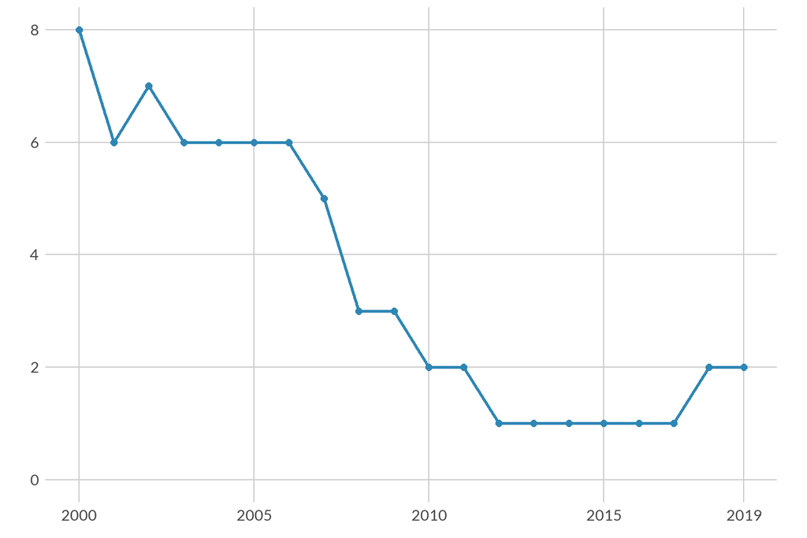

This trend suggests that state policy profiles are becoming more and more unique and individualized over the course of the examined time period, which likely indicates that immigration policy is falling into the state policymaking arena in many dimensions, with less federal uniformity. This explanation is also corroborated by many changes made to the nationwide immigration system following the terrorist attacks in 2001, namely the wave of immigration enforcement adoption at the state level through 287(g) programs. These results also corroborate the “variegated landscape” of immigration policies proposed by Walker & Leitner (2011).

Diversifying state policy profiles can also be illustrated by looking at the types of policies that define the centroid profile each year. Categorizing the 25 policies included in the dataset into five groups in two dimensions enables an understanding of how nationwide state immigration policy profiles change over time. The dimensions of categorization are type of immigration policy (enforcement, public benefits, and integration) and favorability towards immigrants (pro- or anti-immigrant). This typology of immigration policies aligns with norms established in the literature. Note: all public benefits policies are pro-immigrant, yielding five categories. As explored in Figure 2 which depicts the centroid policy scores from 0 to 1, the early centroid profile is mostly bidimensional, with foci in anti-immigrant integration policies and pro-immigrant public benefits policies.

**Figure 2**

[video not shown]

Anti-immigrant policies begin to expand throughout the 2000s in the wake of 9/11 and waves of increasing enforcement, but federal mandates regarding Secure Communities programs in 2015 and 2016 cause a temporary pause in this type of policy. Pro-immigrant integration and enforcement policies also expanded in the 2010s, largely in reaction to anti-immigrant enforcement policies enacted in the late 2000s. Limitations on cooperation with ICE detainer requests and limitations on E-Verify mandates make up most of the pro-immigrant enforcement policy expansion seen here. Overall, each dimension grows in score across the identified time range, supporting the finding that state immigration policy profiles individualize and diversify from 2000 to 2019.

The spatial element to this panel dataset also enables a geographic analysis which can help identify medoid states that are most representative of the global centroid. Across the investigated timeframe and visible in Figure 3, medoid states are remarkably stable, with the vast majority of states closest to the centroid (medoid states were identified until at least four medoids were selected, ordered by distance to the centroid to provide a mostly stable number of medoid states each year, despite fluctuating raw number of medoids as explored in Figure 1) entrenched Republican states.

**Figure 3**

[video not shown]

Indeed, Iowa and South Dakota are the most consistent medoids, with similar smaller, historically-Republican states like Montana, West Virginia, and Alaska (geographically distinct, but demographically similar) also displaying prominently in medoid frequencies. The association between policy, cluster, and partisanship will be further explored in later stages of the analysis.

Although not displayed in Figure 3, tables of state distances to the global centroid also depict those states which are most dissimilar to the global centroid, and thereby have the most distinct or unique policy profiles relative to the nationwide mean. California, Washington, New York, and the District of Columbia are often the most dissimilar states—longstanding fortresses for Democratic policymakers, which is logical given the traditionally Republican partisanship of the aforementioned medoid states. The moderate alignment of the distinction of medoid and dissimilar states with partisan trends indicates that a one-cluster solution may not be faithfully depicting divisions or bifurcations in this dataset; rather, a two-cluster solution that is able to accommodate the divergent partisan trends may be more appropriate.

### Two-cluster solution results

With this natural bifurcation evident in the one-cluster solution, the second stage of analysis shifted to a two-cluster solution. Summary statistics comparing the two clusters are presented in Table 1.

**Table 1**

*Cluster 1 summary statistics*

| Year | N | Distance (own cluster) Mean | Distance (own cluster) SD | Extremity Mean | Extremity SD |
| --- | --- | --- | --- | --- | --- |
| 2000 | 36 | 0.90 | 0.31 | 1.92 | 0.72 |
| 2001 | 36 | 0.97 | 0.37 | 2.11 | 0.91 |
| 2002 | 36 | 1.01 | 0.35 | 2.23 | 0.88 |
| 2003 | 36 | 1.04 | 0.34 | 2.21 | 0.84 |
| 2004 | 36 | 1.05 | 0.34 | 2.25 | 0.84 |
| 2005 | 37 | 1.13 | 0.37 | 2.46 | 0.93 |
| 2006 | 35 | 1.10 | 0.38 | 2.37 | 0.95 |
| 2007 | 32 | 1.10 | 0.39 | 2.32 | 0.97 |
| 2008 | 30 | 1.17 | 0.34 | 2.44 | 0.93 |
| 2009 | 30 | 1.20 | 0.31 | 2.54 | 0.75 |
| 2010 | 26 | 1.23 | 0.30 | 2.49 | 0.83 |
| 2011 | 28 | 1.30 | 0.30 | 2.75 | 1.01 |
| 2012 | 23 | 1.17 | 0.36 | 2.36 | 1.06 |
| 2013 | 28 | 1.23 | 0.35 | 2.56 | 0.98 |
| 2014 | 25 | 1.27 | 0.36 | 2.69 | 1.05 |
| 2015 | 24 | 1.28 | 0.36 | 2.74 | 1.05 |
| 2016 | 27 | 1.33 | 0.35 | 2.87 | 1.05 |
| 2017 | 27 | 1.27 | 0.34 | 2.72 | 0.90 |
| 2018 | 28 | 1.33 | 0.32 | 2.92 | 0.91 |
| 2019 | 27 | 1.34 | 0.31 | 2.98 | 0.92 |

*Cluster 2 summary statistics*

| Year | N | Distance (own cluster) Mean | Distance (own cluster) SD | Extremity Mean | Extremity SD |
| --- | --- | --- | --- | --- | --- |
| 2000 | 15 | 1.33 | 0.18 | 3.08 | 0.76 |
| 2001 | 15 | 1.37 | 0.19 | 3.21 | 0.84 |
| 2002 | 15 | 1.38 | 0.16 | 3.26 | 0.79 |
| 2003 | 15 | 1.33 | 0.20 | 2.99 | 0.82 |
| 2004 | 15 | 1.33 | 0.20 | 2.99 | 0.82 |
| 2005 | 14 | 1.33 | 0.20 | 3.02 | 0.78 |
| 2006 | 16 | 1.39 | 0.19 | 3.14 | 0.73 |
| 2007 | 19 | 1.45 | 0.28 | 3.32 | 1.02 |
| 2008 | 21 | 1.53 | 0.26 | 3.50 | 1.15 |
| 2009 | 21 | 1.61 | 0.25 | 3.84 | 0.96 |
| 2010 | 25 | 1.61 | 0.25 | 3.64 | 1.15 |
| 2011 | 23 | 1.57 | 0.35 | 3.62 | 1.33 |
| 2012 | 28 | 1.53 | 0.33 | 3.42 | 1.39 |
| 2013 | 23 | 1.59 | 0.32 | 3.71 | 1.36 |
| 2014 | 26 | 1.59 | 0.31 | 3.68 | 1.28 |
| 2015 | 27 | 1.59 | 0.30 | 3.71 | 1.28 |
| 2016 | 24 | 1.58 | 0.31 | 3.67 | 1.33 |
| 2017 | 24 | 1.58 | 0.30 | 3.72 | 1.36 |
| 2018 | 23 | 1.57 | 0.27 | 3.67 | 1.21 |
| 2019 | 24 | 1.57 | 0.27 | 3.69 | 1.19 |

Key differences between the two include the clear shrinkage of Cluster 1 and therefore growth of Cluster 2 across the 20 year time period studied and the clear distinction in mean distances to cluster centroid between the two. Outlier members of Cluster 2 like California and Washington—far from their assigned centroid—bring the mean distance to own-cluster centroid up drastically for Cluster 2. This phenomenon also impacts extremity scores for Cluster 2 states, which trend much higher than their Cluster 1 counterparts. Overall, these statistics indicate the distribution of Cluster 1 is much tighter and with fewer outliers than that of Cluster 2, which may be a more diverse cluster in terms of the policy profiles of its members.

Unlike expectations garnered from the one-cluster solution, the centers of each cluster of the two-cluster solution do not revolve around the medoid states and most dissimilar states in the one-cluster solution. Rather, the medoid states from the one-cluster solution remain the medoid states of the Cluster 1 of the two-cluster solution like Iowa, South Dakota, and Alaska, however the second cluster is not characterized by the same states that were most dissimilar in the one-cluster solution, like New York and Washington. Contrastingly, similar but less characteristically or canonically “liberal” states make up the medoids of the second cluster, such as New Jersey, Rhode Island, Delaware, and Pennsylvania. The states that make up each cluster’s medoid profile are shown in Figure 4.

**Figure 4**

[video not shown]

The states most dissimilar to the one-cluster solution centroid are consistently Cluster 2 members, however do not score close to the Cluster 2 centroid. In fact, New York, Washington, and California—hallmarks of dissimilar states in the one-cluster solution—now approximately rank 10th, 16th, and 19th from the Cluster 2 centroid, respectively, on average across all years. This finding is interesting as it begins to characterize the levels of extremity, or uniqueness, state immigration policy profiles take on.

Descriptions of policies are not solely limited to individual states; indeed, each cluster’s policy profile can be characterized in a radar plot similar to the plot used to describe centroid policies of a one-cluster solution. As evidenced in Figure 5, significant differences underscore each cluster’s policy profile.

**Figure 5**

[video not shown]

Cluster 1, in red, is characterized by anti-immigrant policies, across the integration and enforcement dimensions. It is limited in pro-immigrant policies in all dimensions except public benefits policies, which likely reflects the uniformity of adoption of food assistance for LPR children in 2003, instigated by changing federal guidelines on food assistance eligibility. Contrastingly, the Cluster 2 centroid leans much more towards pro-immigrant policies, with drastically greater scores of pro-immigrant public benefits policies relative to Cluster 1. Additionally, starting around the beginning of the 2010s, Cluster 2 states began implementing more pro-immigrant enforcement and integration policies as well, like limitations on E-Verify and state financial aid for undocumented students, respectively. It is important to note that although a cluster is characterized by certain policy dimensions more than others, both clusters do not completely exclude a certain policy dimension, indicating a baseline level of diversity among policy types implemented, regardless of cluster membership.

These policies can be described in further detail. Although categorizing policies into five dimensions provides a comprehensive higher-level overview of changes over time, examining specific, individual policies also proves fruitful. Table 2 displays the most defining policies of Cluster 1. Policies are selected if their standard deviation is the least standard deviation for each year. Although standard deviation is used to identify these policies, mean policy scores are shown in the table for more meaningful interpretation.

**Table 2**

*Defining policies of Cluster 1*

| Year | Secure Communities | Limited cooperation with ICE detainer requests | Prohibition of local E-Verify mandates | Food assistance for LPR children during the five-year bar | Food assistance for LPR adults during the five-year bar | Public health insurance to some unauthorized immigrant children | Public health insurance to LPR adults during the five-year bar | Public health insurance to some unauthorized immigrant adults | Medicaid for pregnant unauthorized immigrants | State financial aid for unauthorized immigrant students | State drivers' license for unauthorized immigrants |
| --- | --- | --- | --- | --- | --- | --- | --- | --- | --- | --- | --- |
| 2000 |  |  |  |  |  | 0 | 0 |  | 0 |  | 0 |
| 2001 |  |  |  |  |  | 0 | 0 | 0 |  |  | 0 |
| 2002 |  |  |  |  |  | 0 | 0 | 0 |  |  | 0 |
| 2003 |  |  |  | 1 |  | 0 | 0 | 0 |  |  |  |
| 2004 |  |  |  | 1 |  | 0 | 0 | 0 |  |  |  |
| 2005 |  |  |  | 1 |  | 0 | 0 | 0 |  |  |  |
| 2006 |  |  |  | 1 | 0 | 0 | 0 | 0 |  |  |  |
| 2007 |  |  | 0 | 1 | 0 | 0 | 0 | 0 |  |  |  |
| 2008 |  |  | 0 | 1 | 0 | 0 | 0 | 0 |  |  |  |
| 2009 |  |  | 0 | 1 | 0 | 0 | 0 | 0 |  | 0 |  |
| 2010 |  |  | 0 | 1 | 0 | 0 | 0 | 0 | 0 | 0 |  |
| 2011 |  | 0 | 0 | 1 | 0 | 0 | 0 | 0 |  | 0 |  |
| 2012 | 1 | 0 | 0 | 1 | 0 | 0 | 0 | 0 | 0 | 0 |  |
| 2013 | 1 |  | 0 | 1 | 0 | 0 | 0 | 0 |  | 0 |  |
| 2014 | 1 |  | 0 | 1 | 0 | 0 | 0 | 0 |  | 0 |  |
| 2015 |  |  | 0 | 1 | 0 | 0 | 0 | 0 |  | 0 |  |
| 2016 |  |  | 0 | 1 | 0 | 0 | 0 | 0 |  |  |  |
| 2017 | 1 |  | 0 | 1 | 0 |  | 0 | 0 |  |  |  |
| 2018 | 1 |  | 0 | 1 | 0 |  | 0 | 0 |  |  |  |
| 2019 | 1 |  | 0 | 1 | 0 |  | 0 | 0 |  |  |  |

Enforcement policies that characterize Cluster 1 include Secure Communities and a lack of limiting E-Verify. Secure Communities began in the Obama Administration and became federally mandated from 2012-2014, and again from 2017-2019, explaining the uniformity in policy adoption. E-Verify mandates, the employment eligibility verification software provided by DHS and the SSA, were limited by some state-level legislatures to prevent the state or substate jurisdictions from implementing E-Verify mandates. Here, Cluster 1 states are characterized by not limiting E-Verify. Public benefits policies also define Cluster 1 policy profiles, namely by not providing food assistance for LPR adults nor public insurance for LPR adults, unauthorized adults, or unauthorized children. As aforementioned, the widespread adoption of food assistance for LPR children is another defining policy of this cluster. The policy profile shifts, however, when examining Cluster 2, as evidenced in Table 3.

**Table 3**

*Defining policies of Cluster 2*

| Year | 287(g) agreement (task force model) | Secure Communities | E-Verify mandate | State omnibus immigration bill | TANF for LPRs after the five-year bar | Food assistance for LPR children during the five-year bar | Medicaid/CHIP for LPR children during the five-year bar | Medicaid for pregnant LPRs during the five-year bar | Medicaid for LPRs after the five-year bar | State financial aid for unauthorized immigrant students | Ban on university enrollment for unauthorized immigrant students |
| --- | --- | --- | --- | --- | --- | --- | --- | --- | --- | --- | --- |
| 2000 |  |  |  |  |  |  | 1 | 1 | 1 |  |  |
| 2001 |  |  |  |  |  |  | 1 | 1 | 1 | 0 |  |
| 2002 | 0 |  |  |  | 1 |  | 1 | 1 | 1 | 0 |  |
| 2003 | 0 |  |  |  | 1 | 1 | 1 | 1 | 1 | 0 |  |
| 2004 | 0 |  |  |  | 1 | 1 | 1 | 1 | 1 | 0 |  |
| 2005 | 0 |  |  |  | 1 | 1 | 1 | 1 | 1 | 0 |  |
| 2006 | 0 |  | 0 |  | 1 | 1 |  | 1 | 1 | 0 |  |
| 2007 | 0 |  | 0 |  |  | 1 |  | 1 |  |  |  |
| 2008 |  |  |  |  |  | 1 |  | 1 |  |  | 0 |
| 2009 |  |  |  |  |  | 1 |  | 1 |  |  | 0 |
| 2010 |  |  |  | 0 |  | 1 |  | 1 |  |  | 0 |
| 2011 |  |  |  | 0 |  | 1 |  |  |  |  | 0 |
| 2012 |  | 1 |  | 0 |  | 1 |  |  |  |  | 0 |
| 2013 |  | 1 |  | 0 |  | 1 |  |  |  |  | 0 |
| 2014 |  | 1 |  | 0 |  | 1 |  | 1 |  |  | 0 |
| 2015 |  |  |  | 0 |  | 1 |  | 1 |  |  | 0 |
| 2016 |  |  |  | 0 |  | 1 |  | 1 |  |  | 0 |
| 2017 |  | 1 |  |  |  | 1 |  | 1 |  |  | 0 |
| 2018 |  | 1 |  |  |  | 1 |  | 1 |  |  | 0 |
| 2019 |  | 1 |  |  |  | 1 |  | 1 |  |  | 0 |

Some similarities exist, like those policies impacted by federal mandates or guidelines (Secure Communities, food assistance for LPR children), however stark differences also arise. Cluster 2 adopts more pro-immigrant public benefits policies, like TANF eligibility after the five-year bar and greater Medicaid accessibility and different integration policies, like limited adoption of state financial aid for undocumented students and no university ban for undocumented immigrants. The main takeaway from comparing the defining policies of each cluster is that while Cluster 1 has a very homogenous policy profile (almost exclusive adoption of anti-immigrant policies or non-adoption of pro-immigrant policies), Cluster 2 has a much more heterogeneous profile, which also reflects the wider range of states included in Cluster 2 and the frequency of states further from the centroid and extreme states in Cluster 2 relative to Cluster 1. This is logical as Cluster 2 states tend to have larger, more institutionally engaged immigrant populations and more complex policy environments than Cluster 1 states, which tend to be lower-immigration, more enforcement-uniform states.

Although implied in the above analysis, the policies that differentiate the two clusters can also be examined with greater scrutiny. These are defined as the policies with the greatest difference of means between the two clusters (greatest three differences in means were selected) and can be found in Table 4.

**Table 4**

*Policies differentiating Clusters 1 and 2, colored by rank*

| Year | Limited cooperation with ICE detainer requests | English as the official state language | Medicaid/CHIP for LPR children during the five-year bar | Medicaid for pregnant LPRs during the five-year bar | Medicaid for pregnant unauthorized immigrants | Public health insurance to LPR adults during the five-year bar |
| --- | --- | --- | --- | --- | --- | --- |
| 2000 |  |  | 0.9444 | 0.9722 |  | 0.8000 |
| 2001 |  |  | 0.9167 | 0.9444 |  | 0.8000 |
| 2002 |  |  | 0.9167 | 0.9444 |  | 0.8000 |
| 2003 |  |  | 0.9167 | 0.9444 |  | 0.7333 |
| 2004 |  |  | 0.9167 | 0.9444 |  | 0.7333 |
| 2005 |  |  | 0.8919 | 0.9189 |  | 0.7857 |
| 2006 |  |  | 0.8518 | 0.9143 |  | 0.6875 |
| 2007 |  |  | 0.8109 | 0.9062 |  | 0.6316 |
| 2008 |  |  | 0.7286 | 0.9667 | 0.6810 |  |
| 2009 |  | 0.5952 | 0.8048 | 0.8667 |  |  |
| 2010 |  |  | 0.6462 | 0.9615 | 0.6400 |  |
| 2011 |  | 0.6320 | 0.7702 | 0.7780 |  |  |
| 2012 |  |  | 0.7345 | 0.9208 | 0.6071 |  |
| 2013 |  | 0.6320 | 0.7345 | 0.7422 |  |  |
| 2014 |  | 0.6123 | 0.7246 | 0.8000 |  |  |
| 2015 |  | 0.6620 | 0.7593 | 0.7917 |  |  |
| 2016 |  | 0.7130 | 0.6620 | 0.7037 |  |  |
| 2017 |  | 0.7130 | 0.6250 | 0.7037 |  |  |
| 2018 | 0.6949 | 0.6677 |  | 0.6071 |  |  |
| 2019 | 0.6574 | 0.7130 |  | 0.6296 |  |  |

Almost every year studied, two policies play the core role in differentiating the two clusters: Medicaid for pregnant LPRs and Medicaid for LPR children. Other policies do differentiate the two clusters but do so either secondary to one of the aforementioned Medicaid policies or inconsistently year-over-year. Hence, Medicaid for vulnerable LPRs is the policy type that reliably differentiates the clusters the most over the studied years. Finally, important to note is the decreasing differences in means year-over-year, which serves as another indication of increasing policy profile diversity of states leading up to 2019.

The final part of the two-cluster solution analysis involved identifying the determinants of cluster membership. Results from the first set of regression, testing determinants of cluster assignment, are presented in Table 5. Model 1 presents a naïve model with covariates garnered from the literature. Model 2 expands on Model 1 by including unit and time fixed effects. Due to the high frequency of limited variance in the dependent variable, cluster assignment (i.e. many states did not change cluster membership during the studied period), the fixed effects model presented in Model 2 has a much smaller sample size than that of Model 1. Hence, the results garnered from Model 2 are best generalized to findings regarding the determinants of cluster switching not cluster assignment. Although this limits the external validity of these models, making this distinction helps maintain a rigorous model specification. Model 1, lacking fixed effects, may be incomplete and therefore lack internal validity. The presentation of both models best balances internal and external validity.

**Table 5**

*Odds ratios for determinants of cluster membership*

|  | Naïve model | Fixed-effects model |
| --- | --- | --- |
| State government partisanship (0 = entirely Republican, 1 = entirely Democratic) | 7.31* | 16.41* |
|  | (5.78) | (22.72) |
| Population | 1.00 | 1.00 |
|  | (0.00) | (0.00) |
| Prop. Latino | 1.01 | 2.35 |
|  | (0.24) | (4.79) |
| Prop. white | 1.07 | 0.60 |
|  | (0.15) | (0.37) |
| Prop. unemployed | 1.47 | 1.18 |
|  | (0.33) | (0.67) |
| Prop. foreign-born | 1.89 | 0.11 |
|  | (1.24) | (0.19) |
| Prop. undocumented | 0.00 | 0.00 |
|  | (0.00) | (0.00) |
| Prop. in poverty | 1.37 | 0.60 |
|  | (0.28) | (0.35) |
| Prop. old (65+) | 2.86** | 160.29* |
|  | (0.99) | (358.68) |
| Year FE |  | Y |
| State FE |  | Y |
| N | 909 | 320 |
| Standard errors in parentheses |  |  |
| * p < 0.05, ** p < 0.01, *** p < 0.001 |  |  |

In Model 1, state government partisanship and the population proportions for 65+ in age are both statistically significant at the $\alpha = 0.05$ significance level. When examining Model 2, the more internally-valid model, state government partisanship and the population proportion for age are again the only covariates that are statistically significant, which suggests that these two variables are the drivers of state cluster membership (or switching) given the parity between models. Indeed, state governments that are completely controlled by Democrats (governor, house/assembly, and senate), are *16.41 times more likely* to be assigned to or switch to Cluster 2 than governments controlled completely by Republicans. Separately, a 10 percentage point increase in the population proportion of the elderly population is correlated with 1.66 $(e^{\beta \times 0.10} = (e^{\beta})^{0.10} = OR^{ 0.10})$ greater odds of clustering with Cluster 2 instead of Cluster 1, a treatment effect of much lesser magnitude relative to the effect of state government partisanship. These results suggest that state government partisanship is an important determinant of cluster membership and switching.

Secondary regressions were used to test whether the same battery of policy determinants were able to predict Euclidean distances yielded from the two-cluster solution: distance to own cluster and extremity. These results can be found in Table 6.

**Table 6**

*Coefficients of policy determinants on two-cluster solution Euclidean distances*

| Covariate | Cluster 1 Own-cluster distance | Cluster 1 Extremity | Cluster 2 Own-cluster distance | Cluster 2 Extremity |
| --- | --- | --- | --- | --- |
| State government partisanship (0 = entirely Republican, 1 = entirely Democratic) | -0.07 | -0.24 | 0.11* | 0.67** |
|  | (0.06) | (0.18) | (0.05) | (0.21) |
| Population | 0.00 | 0.00 | 0.00 | 0.00 |
|  | (0.00) | (0.00) | (0.00) | (0.00) |
| Prop. Latino | 0.09 | 0.22 | -0.09* | -0.22 |
|  | (0.08) | (0.19) | (0.04) | (0.17) |
| Prop. white | -0.01 | -0.01 | -0.01 | -0.03 |
|  | (0.03) | (0.10) | (0.03) | (0.11) |
| Prop. unemployed | 0.01 | 0.04 | -0.02 | -0.10 |
|  | (0.03) | (0.06) | (0.02) | (0.10) |
| Prop. foreign-born | 0.02 | -0.04 | -0.02 | -0.17 |
|  | (0.11) | (0.29) | (0.06) | (0.21) |
| Prop. undocumented | 2.31 | 10.89 | 4.22 | 16.83 |
|  | (6.43) | (19.33) | (6.34) | (16.58) |
| Prop. in poverty | -0.02 | -0.06 | 0.04 | 0.11 |
|  | (0.03) | (0.076) | (0.03) | (0.11) |
| Prop. old (65+) | 0.07 | 0.32 | -0.03 | -0.04 |
|  | (0.07) | (0.22) | (0.06) | (0.25) |
| Year FE | Y | Y | Y | Y |
| State FE | Y | Y | Y | Y |
| N | 545 | 545 | 364 | 364 |
| Standard errors in parentheses |  |  |  |  |
| * p < 0.05, ** p < 0.01, *** p < 0.001 |  |  |  |  |

Interestingly, the battery of policy determinants—including state government partisanship—had no predictive power of distance to own-cluster centroid and extremity for Cluster 1 states, however played a much more predictive role in estimating these metrics for Cluster 2 states. No covariates were statistically significant in estimating these metrics among Cluster 1 states, however state government partisanship was statistically significant in Cluster 2 models. Furthermore, switching from a state government controlled completely by Republicans to one controlled completely by Democrats was found to correlate with a 0.11 unit increase in Euclidean distance to own-cluster centroid, as well as a 0.67 unit increase in extremity score. These results align with previous findings regarding the greater distribution of own-centroid distances and extremity scores among Cluster 2 states.

## Discussion

Understanding the differences between the two identified clusters is a central result of this investigation. Although partisanship and age were found to be important indicators of cluster membership, other structural differences also exist between the clusters, especially through the lens of state membership. Indeed, Cluster 1 is not only characterized by state governments that lean more Republican, but also by greater homogeneity in policy profiles. Its key member states like Iowa, South Dakota, and Alaska imply that Cluster 1 members often experience less immigration relative to Cluster 2 counterparts, with relatively low flows of immigrants, however implement symbolically restrictive policy profiles, oftentimes in alignment with or triggered by each other. This is a critical understanding for a policymaking context as strategies for change or reform in these states may vary as their incentive structure is different from canonical high-immigration states like California and Texas. Indeed, if high-enforcement policy profiles are a form of political signaling and not actually in response to contemporary contexts on the ground, enacting change in these policies may require distinct resources. Separately, tracking homogeneity and changes in policy profiles could help identify “flagship” states that serve as the most “innovative” laboratories of democracy and serve as a baseline for similar states to mirror. For example, Arizona’s 2010 omnibus immigration bill SB 1070 became the template for a plethora of similar omnibus bills enacted in similar states before the Supreme Court struck down many of the provisions included in laws of this type.

Cluster 2, however, characterized by more Democratic state governments, is made up of states with much greater diversity, especially among immigrant populations. Canonical border states like California and Texas are both Cluster 2 states, for example, and have much more complex and diverse policy profiles often reflecting the diversity of their native-born and foreign-born populations. These states face unique governance challenges when compared not only to Cluster 1 counterparts, but also their sibling Cluster 2 states (given the wider distribution experienced among Cluster 2 states) to the point that their heterogeneity is not well captured by a two-cluster solution. Federal policy should account for the larger burden these states face in managing immigration policy and consider targeting resource allocation accordingly. Additionally, the extremity of states like California and Texas—states often referenced in the immigration policy discourse—are just that: extreme. In a policy context characterized by polarization and a vast partisan rift, knowing that the extreme policy profiles are not representative of the majority of states can help ease interpersonal political divides and identify common ground for policymaking.

Additionally, the findings suggest a minimal role of 287(g) programming in defining and differentiating clusters. Indeed, other enforcement policies, like E-Verify mandates, Secure Communities programs, and state omnibus bills are more representative of a state’s enforcement environment. The task force model of the 287(g) program is the only 287(g) variant that plays a role in describing cluster policies, and helps define Cluster 2’s stance on immigration enforcement (unfavorable towards enforcement). These findings suggest that certain already-published works in the literature, and publications moving forwards, should more carefully consider use of proxies of immigration enforcement to maintain rigorous construct validity and valid operationalization. Unless very specific causal mechanisms are theorized or a program is undergoing evaluation, indexing enforcement metrics could more faithfully represent state immigration enforcement policy profiles.

Other key findings of this study revolve primarily around the policy types that characterize and differentiate the clusters as well as the connections between cluster membership/switching and state government partisanship. Understanding public benefits policies, specifically Medicaid for vulnerable LPRs, as the primary policy type differentiating dominant policy profiles across the country is an important addition to the immigration literature, which often focuses on enforcement policies like E-Verify mandates, Secure Communities, and 287(g) programs. However, this exploratory analysis identifies distinct policies that may play a more important or unique role in determining state policy profiles.

The centrality of Medicaid access for vulnerable LPRs to differentiating policy profile types between states suggests that public benefits policy—instead of enforcement policy—may be the more distinctive immigration policy type across the nation. As with changes to federal guidelines for SNAP eligibility, which enabled much greater nationwide homogeneity in food assistance for LPR children policy across all states in 2003, federal guidance on LPR eligibility for public benefits programs like Medicaid could create more meaningful subnational uniformity, thereby reducing state-level disparities and producing more consistent financial and health outcomes for immigrant populations nationwide. This is especially important given the initial findings of increasing fragmentation and individualization among state immigration policy profiles. Stronger federal standards could create more equitable outcomes for immigrants across all states.

Results that identify state government partisanship as a determinant of cluster membership, and by extension, state policy profiles, underscores the highly partisan nature of immigration policymaking. Policymakers aiming to reform state-level policy may face structural partisan barriers to cooperation and policymaking, evaluation, and revision which may be difficult to overcome without addressing underlying structural contexts and incentives. The finding that partisan covariates predict distance to own-cluster centroid and extremity scores only among Cluster 2 states implies that determinants of immigration policy and policy innovation operate differently across the partisan spectrum.

Ultimately, the single most important takeaway from this analysis is that the main difference between what Democrats and Republicans consider the role of state immigration policy is whether state governments should provide public benefits to vulnerable populations.

## Conclusion

One limitation to this research design is the conditionality and subjectivity of k-means clustering. Given the randomness of the initial centroid selection in the clustering process, cluster assignments can vary without a set seed. For the purposes of this analysis, a seed was set during the clustering process to maintain stable clusters. However, edge states—especially states defined as most extreme—may fluctuate between clusters depending on centroid positions each iteration of clustering. Further investigation could test the stability of these clusters using this vector of policies with iterative clustering process and comparisons of these cluster solutions using Adjusted Rand Indices. Additionally, repeated clustering could serve as a form of robustness check by changing the vector of policy variables that forms the basis of the clustering algorithm. Subtracting key differentiator variables identified in the above analysis could serve to further analyze the role of specific policies on cluster stability. Separately, using similar vectors of policies, like the Migrant Integration Policy Index (MIPEX) could serve to check the robustness of the results garnered here using the Urban Institute State Immigration Policy Resource.

The two-cluster solution identified here is also limited given its inability to capture certain extreme states like California and Texas. While in this two-cluster solution these states are identified as outliers, additional clusters or utilization of a more nuanced and multi-dimensional classification framework could identify further latent constructs informing the extremity of states like these. In a broader sense, examining immigration policy profiles and state-level heterogeneity would benefit from a more multi-dimensional framework; although partisanship is found to be an important determinant of state-level immigration policy, it is not the sole determinant nor the sole characterization of these policy profiles and expanding the framework we look at immigration policy—and state-level policy more broadly—from solely a partisan bifurcation, could enable greater understanding of policy determinants and creative solutions to accomplish policy goals.

Additionally, future investigations could update findings here—or the original SIPR dataset—with data from 2020 through the present. The impact of the COVID-19 pandemic on immigration policy—namely through Trump’s utilization of Title 42 to expel migrants, including asylees, under the Public Health Services Act—and tokenization of immigrant rights as a policy area to publicize and attack during the second Trump Administration have certainly changed the federal immigration policy landscape, likely with downstream effects on subnational jurisdictions, as well. Analyzing the role of federal policy on state policy would serve as an interesting extension to the current investigation and further broaden our understanding of determinants and characterizations of state-level immigration policy profiles.

## References

Border Patrol History. (2026). In *U.S. Customs and Border Protection*. https://www.cbp.gov/border-security/along-us-borders/history

Borjas, G. J. (2003). Welfare reform, labor supply, and health insurance in the immigrant population. *Journal of Health Economics*, *22*(6), 933–958. https://doi.org/10.1016/j.jhealeco.2003.05.002

Capps, R. (2009). *Local Enforcement of Immigration Laws: Evolution of the 287(g) Program and Its Potential Impacts on Local Communities* (p. 155). Police Foundation.

Capps, R., Rosenblum, M. R., Rodríguez, C., & Chishti, M. (2011). *Delegation and Divergence: A Study of 287(g) State and Local Immigration Enforcement*. Migration Policy Institute.

Center for Migration Studies. (2022). *Undocumented Immigrants in the United States, by State and Year, 2010-2019*. https://cmsny.org/data-undocumented-state-2010-to-2019/

*Chy Lung v. Freeman, 92 U.S. 275*. (1875). https://supreme.justia.com/cases/federal/us/92/275/

Filindra, A., & Kovács, M. (2012). Analysing US State Legislative Resolutions on Immigrants and Immigration: The Role of Immigration Federalism***. *International Migration*, *50*(4), 33–50. https://doi.org/10.1111/j.1468-2435.2010.00658.x

Hamutal Bernstein, Paola Echave, Heather Koball, Joseph Stinson, & Susi Martinez. (2022). *State Immigration Policy Resource (2022 update)*. UrbanInstitute/state-immigration. https://github.com/UrbanInstitute/state-immigration

*Henderson v. Mayor of City of New York, 92 U.S. 259*. (1875). https://supreme.justia.com/cases/federal/us/92/259/

In Tied Presidential Race, Harris and Trump Have Contrasting Strengths, Weaknesses. (2024). In *Pew Research Center*. https://www.pewresearch.org/politics/2024/09/09/issues-and-the-2024-election/

Julia Gelatt, Hamutal Bernstein, Heather Koball, Charmaine Runes, & Eleanor Pratt. (2017). *State Immigration Policy Resource*. UrbanInstitute/state-immigration. https://github.com/UrbanInstitute/state-immigration

Klarner, C. (2013). *State Partisan Balance Data, 1937 - 2011*. Harvard Dataverse. https://doi.org/10.7910/DVN/LZHMG3

Kostandini, G., Mykerezi, E., & Escalante, C. (2014). The Impact of Immigration Enforcement on the U.S. Farming Sector. *American Journal of Agricultural Economics*, *96*(1), 172–192. https://doi.org/10.1093/ajae/aat081

Motomura, H. (2010). The Rights of Others: Legal Claims and Immigration Outside the Law. *Duke Law Journal*, *59*(8), 1723–1786. http://www.jstor.org.ezproxy4.library.arizona.edu/stable/27806865

National Conference of State Legislatures. (2026). *State Partisan Composition*. https://www.ncsl.org/about-state-legislatures/state-partisan-composition

Nguyen, M. T., & Gill, H. (2016). Interior Immigration Enforcement: The Impacts of Expanding Local Law Enforcement Authority. *Urban Studies*, *53*(2), 302–323. https://www-jstor-org.ezproxy2.library.arizona.edu/stable/26146250

Pew Research Center. (2019). *Unauthorized immigrant population trends for states, birth countries and regions*. https://www.pewresearch.org/race-and-ethnicity/feature/unauthorized-trends/

SB 1070 at the Supreme Court: What’s at Stake. (n.d.). In *American Civil Liberties Union*. Retrieved April 29, 2026, from https://www.aclu.org/sb-1070-supreme-court-whats-stake

Schuck, P. H. (2009). Taking Immigration Federalism Seriously. *The Forum*, *7*(3). https://doi.org/10.2202/1540-8884.1321

Spiro, P. (1997). Learning to Live with Immigration Federalism. *Connecticut Law Review*, *29*. https://www.researchgate.net/publication/323560943_Learning_to_Live_with_Immigration_Federalism

The Cost of Immigration Enforcement and Border Security. (2024). In *American Immigration Council*. https://www.americanimmigrationcouncil.org/fact-sheet/the-cost-of-immigration-enforcement-and-border-security/

The Personal Responsibility and Work Opportunity Reconciliation Act of 1996. (1996). In *Office of the Assistant Secretary for Planning and Evaluation*. http://aspe.hhs.gov/reports/personal-responsibility-work-opportunity-reconciliation-act-1996

Tumlin, K. C. (2004). Suspect First: How Terrorism Policy Is Reshaping Immigration Policy. *California Law Review*, *92*(4), 1173–1239. https://doi.org/10.2307/3481320

U.S. Census Bureau. (n.d.-a). *American Community Surveys (1-Year Estimates)*.

U.S. Census Bureau. (n.d.-b). *U.S. Decennial Census*.

Walker, K. E., & Leitner, H. (2011). The Variegated Landscape of Local Immigration Policies in the United States. *Urban Geography*, *32*(2), 156–178. https://doi.org/10.2747/0272-3638.32.2.156

Wallace, S. P., Young, M.-E. D. T., Rodríguez, M. A., & Brindis, C. D. (2019). A social determinants framework identifying state-level immigrant policies and their influence on health. *SSM - Population Health*, *7*. https://doi.org/10.1016/j.ssmph.2018.10.016

Wishnie, M. J. (2001). Laboratories of Bigotry? Devolution of the Immigration Power, Equal Protection, and Federalism. *New York University Law Review*, *76*(2). https://nyulawreview.org/issues/volume-76-number-2/laboratories-of-bigotry-devolution-of-the-immigration-power-equal-protection-and-federalism/

Wong, TomK. (2012). 287(g) and the Politics of Interior Immigration Control in the United States: Explaining Local Cooperation with Federal Immigration Authorities. *Journal of Ethnic & Migration Studies*, *38*(5), 737–756. https://doi.org/10.1080/1369183X.2012.667983